# Viewership Report - GoT

Bartłomiej Ramotowski

2025-05-18

## *Game of Thrones* – A Cultural Phenomenon

*Game of Thrones* is an American fantasy drama television series created by David Benioff and D. B. Weiss. The series is based on George R. R. Martin’s series of fantasy novels, A Song of Ice and Fire. The series takes place on the fictional continents of Westeros and Essos, and chronicles the power struggles among noble families as they fight for control of the Iron Throne of the Seven Kingdoms. The series starts when House Stark, led by Lord Eddard “Ned” Stark (Sean Bean), is drawn into schemes surrounding King Robert Baratheon (Mark Addy).

[figure not shown]

Title screen of Game of Thrones

## Viewership Overview

Below is a dataset of average U.S. viewership (in millions) per episode, based on data available on [Wikipedia](https://en.wikipedia.org/wiki/List_of_Game_of_Thrones_episodes).

```
## # A tibble: 15 × 3
##    Season Episode Viewership
##     <dbl>   <dbl>      <dbl>
##  1      1       1       2.22
##  2      1       2       2.2
##  3      1       3       2.44
##  4      1       4       2.45
##  5      1       5       2.58
##  6      1       6       2.44
##  7      1       7       2.4
##  8      1       8       2.72
##  9      1       9       2.66
## 10      1      10       3.04
## 11      2       1       3.86
## 12      2       2       3.76
## 13      2       3       3.77
## 14      2       4       3.65
## 15      2       5       3.9
```

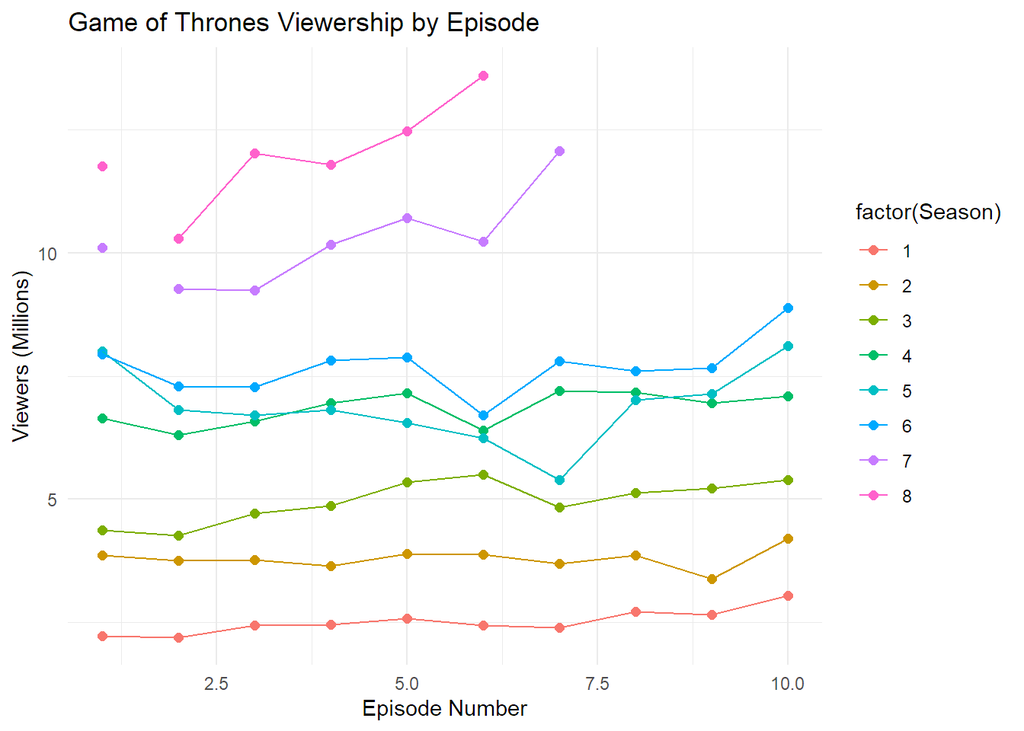

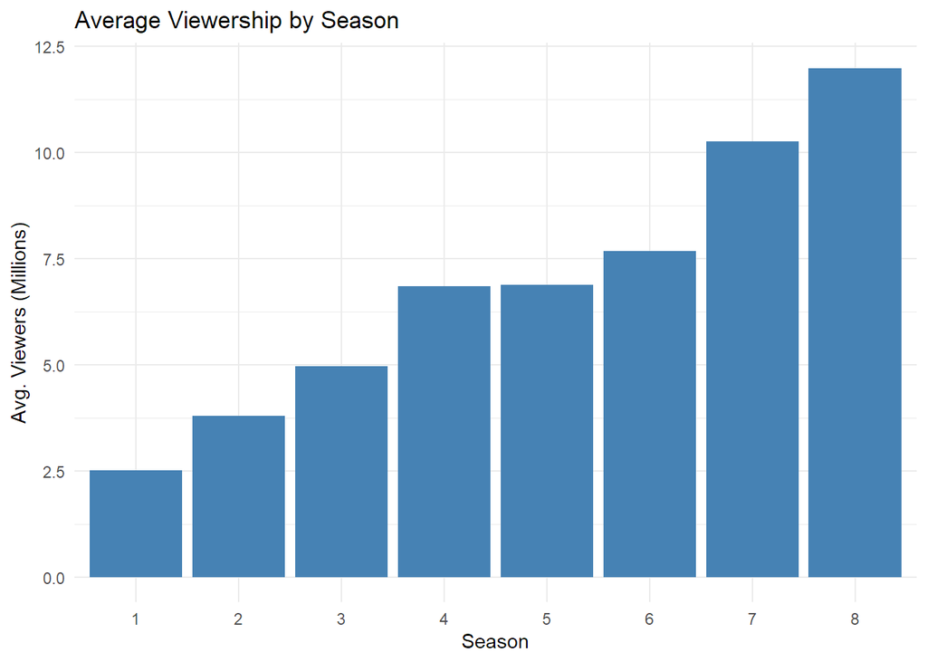

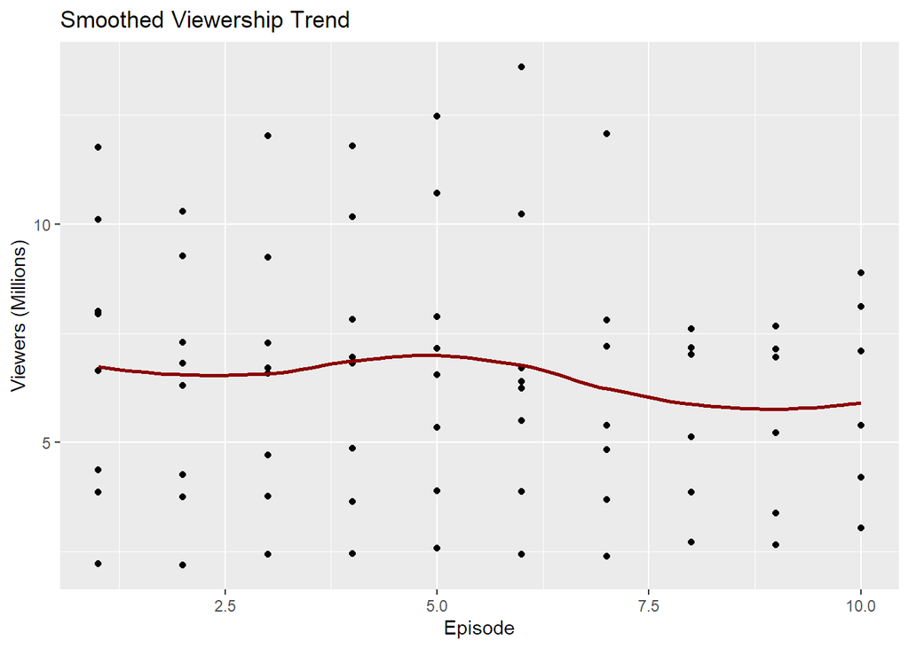

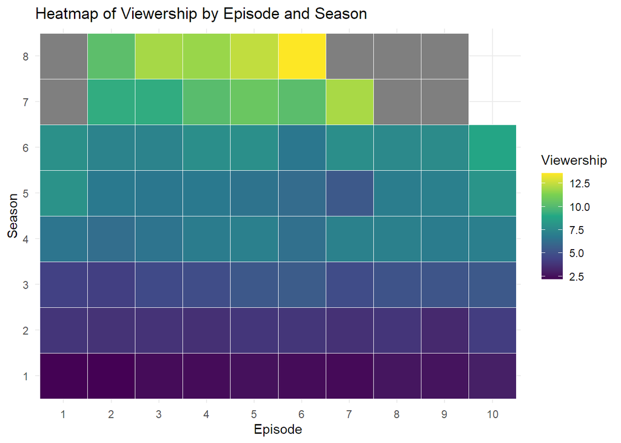